## Ein Gespräch mit Stück-Dramaturg Lars Gebhardt.

# Ein narzisstischer Spiegelsaal

## Regisseur Jan Bosse bringt Gioacchino Rossinis absurde Krönungsoper „Il viaggio a Reims“ auf die Bühne der Deutschen Oper Berlin.

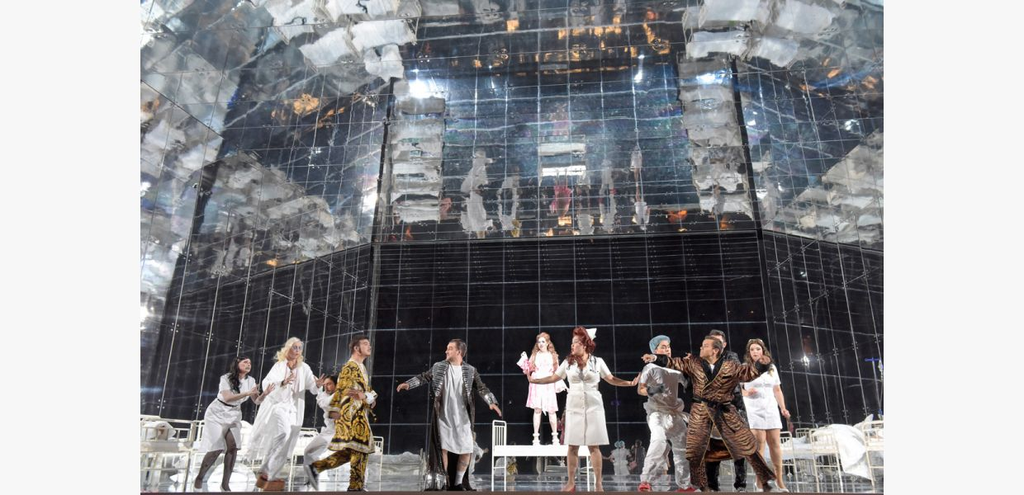

[zurück](https://deutscheoperberlin.de/de_DE/blog)

[Il viaggio a Reims](https://deutscheoperberlin.de/de_DE/production/il-viaggio-a-reims.1336951)

**„Il viaggio a Reims“ entstand zunächst für einen konkreten Anlass: die Krönungsfeierlichkeiten Karl X. in Paris. Gioacchino Rossini war sich der kurzen Halbwertzeit der Oper bewusst – er zog das Werk nach den wenigen Aufführungen zurück und verwertete viele Nummern in „Le comte Ory“ wieder. Warum wird die Oper, nachdem sie in den 1980er Jahren für den Konzertsaal wiederentdeckt wurde, in den letzten Jahren zunehmend szenisch reanimiert?**  
**Jan Bosse:** Der Ensemblegedanke dieser Oper scheint mir sehr modern. Eine Gruppe von Menschen sitzt fest – und ergeht sich in absurden Aktionen. Es gibt keine dramatische Story für einige wenige Solisten, sondern eine revueartige Abfolge von kontrastierenden, sehr unterhaltsamen ‚Nummern‘. Diese Nummern arbeiten dann mit klischeehaften Grundsituationen der Oper an sich: der unglücklich Liebende, die leidende Diva, das eifersüchtig sich umkreisende Paar, der komische Kauz. Diese große Nummernshow, aber auch das gemeinsame Erzählen eines Ensembles ist für einen Regisseur, der vom Schauspiel kommt, äußerst reizvoll!

**Die Situation ist grundsätzlich absurd: Diverse Contessas, Lords, Barone und Dons aus verschiedenen europäischen Ländern wollen zur Krönung des Königs nach Reims fahren. Sie sind aber in einem Hotel gestrandet und es gibt weder Pferde noch Kutschen – da beschließen sie kurzerhand selbst zu feiern. Wie gehen Sie als Regisseur mit dem äußerlichen szenischen Stillstand um?**  
**Jan Bosse:** Dieser Stillstand ist unsere absurde Triebfeder. Wir sehen einen Schlafsaal – ist es eine Kurklinik? Ein Sterbehospiz? Das Asyl des todmüden Europäers? Allabendlich schwingen sich die Insassen zur großen Reise auf – um endlich die Krönung des neuen Königs zu feiern – und bleiben in abstrusen Ritualen stecken. Immer wird ein Grund gefunden, lieber doch lethargisch ins Bett zurückzusinken oder in einem Ersatzfest sich selbst in allem Überfluss und Überdruss zu feiern. Es ist ein selbstgewähltes Gefängnis. Ein narzisstischer Spiegelsaal, der die Realität tunlichst draußen hält. Schließlich ist der Musik in ihrer Virtuosität, den Koloraturen, Spitzentönen und gekonnten Verzierungen ein gutes Maß Narzissmus und Selbstverliebtheit eingeschrieben. Das muss man dann auch bedienen.

**Rossini und sein Librettist Luigi Balochi sparen dabei nicht mit europäischen Klischees: Der feurige Spanier und der eifersüchtige Russe kämpfen um die schöne Polin. Die exaltierte Französin denkt nur an ihre Garderobe. Der Deutsche versucht Streitigkeiten zu schlichten etc. In den 1820erJahren war ein geeintes und einmütig nebeneinander lebendes Europa Wunschdenken. Heute wird die europäische Idee von verschiedensten Seiten wieder heftig in Frage gestellt. Wie verhält sich das Stück dazu? Gibt es Raum für eine europäische Utopie?**  
**Jan Bosse:** Die europäische Idee ist im Stück noch im Werden begriffen, inklusive der absurden Hoffnung auf Rettung durch die Reste des Absolutismus unter Herrschaft des christlichen Kreuzes. Rossinis Krönungsoper wurde zusammen mit ihrem gefeierten Gegenstand, Karl X., schon fünf Jahre später durch die Pariser Julirevolution weggefegt. Wir befinden uns mit unserer Lesart eher am Ende dieses Prozesses, wo die europäische Idee nur noch zwanghaft aufrechterhalten wird, da wahrhaft verbindende Momente fehlen und die Angst vor allgemeinem Verfall und unberechenbarem Chaos stärker ist als der Mut, etwas Gemeinsames zu wagen. Der Stillstand im Stück, der mit Aktionismus und – beim großen Fest am Ende – auch mit Hedonismus überspielt wird, weist einige spannende Parallelen zu unserem heutigen Europa auf.

**Rossini nahm diese erste Oper, die er für Frankreich schrieb – und die seine letzte in italienischer Sprache sein sollte – zum Anlass, ein „Best of“ der italienischen Oper zu zeigen: Gleich einer Nummernrevue sehen und hören wir eine Arien-Parodie der großen opera seria-Heroine, ein ausgefeiltes Vokalsextett, großartige Duette, die für die opera buffa so typische Plapperarie und über allem thront das „Gran pezzo concertato“ für 14 Stimmen. Es ist wirklich ein musikalisches Feuerwerk, das Rossini da zündet. Hilft das Revuehafte beim Inszenieren oder steht es eher im Weg?**  
**Jan Bosse:** Ja, die Oper ist eine Art Revue. Aber es ist eine Revue, der immer wieder subversiver Sand ins Getriebe gestreut wird, sodass die Maschine ins Stottern und Stocken gerät. Aber „The Show must go on“: „Morgen Abend wieder von vorn!“ ist das Motto. Und es macht natürlich auch Spaß, sich als Regisseur nicht um eine mögliche psychologische Logik oder Wahrscheinlichkeit zu kümmern, sondern dem Affen Zucker zu geben und aus dem Grundsetting heraus von einer absurden, komischen Nummer in die nächste zu taumeln.

Verwandte Themen

[Gioacchino Rossini](https://deutscheoperberlin.de/de_DE/blog?tag=Gioacchino%20Rossini)

[Il viaggio a Reims](https://deutscheoperberlin.de/de_DE/blog?tag=Il%20viaggio%20a%20Reims)

[Jan Bosse](https://deutscheoperberlin.de/de_DE/blog?tag=Jan%20Bosse)